# The Effects of a 16-week Aerobic Exercise and Mindfulness-based Intervention on Chronic Psychosocial Stress: A Nonrandomized Pilot and Feasibility Trial

Guy A. Prochilo

December 01, 2019

This R Markdown report reproduces the results found in the above manuscript.

*Note*: data from the original publication are not publicly available on the advice of the Monash University Human Research Ethics Committee. This is because the approved ethics application did not include provisions for public access to data. The deidentified data are available from the corresponding author, upon a reasonable request.

*Note*: tables generated in this R Markdown report can be reproduced inside an R environment using the commands preceding each table. However, tables in this report have been formatted for presentation purposes using the DT::datatable() function. See the raw R Markdown code in `rm_report.Rmd` for details.

# 1 Prepare R Session

**1. Load and attach required packages**

- R Markdown will load and attach the required packages by sourcing the `libraries.R` file
- Robust statistical analysis scripts are sourced from the Rallfun-v35 script file
  - Wilcox, R. R. (2018). Rallfun-v35. Retrieved from https://dornsife.usc.edu/labs/rwilcox/software/

```r
source("libraries.R")
source("Rallfun-v35.txt")
```

**2. Import data**

- R Markdown will source the `import_data.R` script file
- This file imports the study data and sorts it into a form required for analysis. This includes:
  - Sorting data into long and wide format
  - Defining variable classes
  - Removing data with incomplete cases for analysis of aerobic economy

```r
source("import_data.R")
```

**3. Source the analysis scripts**

- R Markdown will source the analysis script file for this project: `ProchFun_stress-v1.R`
- This file includes all scripts required for reproducing all analyses

```r
source("ProcFun_stress-v1.R")
```

[output not shown]

# 2 In-text Tables

## 2.1 Table 1

- Reproduce Table 1: Baseline demographic characteristics of participants

```r
baseline.res(sav2csv = TRUE, sav2dir = c("results","tables","table1.csv"))
```

|  | all | pss.ch<0 | pss.ch>=0 |
| --- | --- | --- | --- |
| total | 17 (100.00%) | 12 (70.59%) | 5 (29.41%) |
| baseline.pss | 20.12 (7.56) | 23.50 (5.35) | 12.00 (5.74) |
| age | 22.88 (2.71) | 23.08 (2.84) | 22.40 (2.61) |
| male | 8 (47.06%) | 5 (29.41%) | 3 (17.65%) |
| female | 9 (52.94%) | 7 (41.18%) | 2 (11.76%) |
| caucasian | 11 (64.71%) | 7 (41.18%) | 4 (23.53%) |
| asian | 6 (35.29%) | 5 (29.41%) | 1 (5.88%) |
| baseline.vo2max | 45.34 (7.44) | 45.81 (5.58) | 44.20 (11.54) |
| baseline.bmi | 23.29 (2.65) | 23.96 (2.45) | 21.68 (2.64) |

## 2.2 Table 2

- Reproduce Table 2: Summarized dosage results

```r
  descrip.res(dvs = c("attendance.pcnt.1",
                      "meditation.tot.1",
                      "runs.tot.1",
                      "mean.pcnt.vo2max.1",
                      "distance.km.tot.1",
                      "runtime.tot.1"),
              dataset = dat.wide,
              sav2csv = TRUE,
              sav2dir = c("results","tables","table2.csv"))
```

|  | M (SD) | Range |
| --- | --- | --- |
| attendance.pcnt.1 | 79.41 (11.64) | 62.50 - 100.00 |
| meditation.tot.1 | 24.81 (2.69) | 19.33 - 29.42 |
| runs.tot.1 | 34.76 (5.39) | 25.00 - 42.00 |
| mean.pcnt.vo2max.1 | 70.54 (6.69) | 56.78 - 82.15 |
| distance.km.tot.1 | 228.10 (81.67) | 143.80 - 474.27 |
| runtime.tot.1 | 24.50 (6.82) | 17.99 - 45.37 |

## 2.3 Table 3

- Reproduce Table 3: Summarized results for pre-test (T0), post-test (T1), and gains (T1-T0) for psychosocial stress factors, mindfulness, emotion regulation factors, and maximal aerobic capacity

```r
pair.test.table2(dvs = c("pss",
                          "sdass",
                          "adass",
                          "ddass",
                          "who",
                          "maas",
                          "erq.cr",
                          "rrs.br",
                          "pswq",
                          "vo2max"),
                  long.dataset = dat.long,
                  sav2csv = TRUE,
                  sav2dir = c("results", "tables", "table3.csv"))
```

|  | T0: M (SD) | T1: M (SD) | Gain: M (SD) [95% CI] | dpre [95% CI] | t | p | pR |
| --- | --- | --- | --- | --- | --- | --- | --- |
| pss | 20.12 (7.56) | 15.88 (4.54) | -4.24 (7.01) [-7.84, -0.63] | -0.56 [-1.14, -0.06] | -2.49 | .024 | .020 |
| sdass | 28.59 (6.07) | 24.00 (5.87) | -4.59 (4.17) [-6.73, -2.44] | -0.76 [-1.24, -0.52] | -4.54 | &lt;.001 | &lt;.001 |
| adass | 19.88 (4.82) | 20.00 (6.60) | 0.12 (4.55) [-2.22, 2.46] | 0.02 [-0.43, 0.53] | 0.11 | .916 | .789 |
| ddass | 23.76 (7.21) | 19.76 (4.63) | -4.00 (6.32) [-7.25, -0.75] | -0.56 [-0.98, -0.15] | -2.61 | .019 | .015 |
| who | 54.35 (18.55) | 64.00 (12.65) | 9.65 (15.75) [1.55, 17.75] | 0.52 [0.19, 1.02] | 2.53 | .023 | .028 |
| maas | 3.78 (0.70) | 4.00 (0.66) | 0.22 (0.75) [-0.17, 0.60] | 0.31 [-0.24, 0.88] | 1.18 | .256 | .225 |
| erq.cr | 4.31 (1.46) | 5.18 (1.18) | 0.86 (1.04) [0.33, 1.39] | 0.59 [0.22, 1.15] | 3.43 | .003 | .003 |
| rrs.br | 11.00 (4.14) | 9.59 (3.36) | -1.41 (2.55) [-2.72, -0.10] | -0.34 [-0.75, -0.07] | -2.28 | .037 | .051 |
| pswq | 50.12 (16.19) | 43.94 (11.26) | -6.18 (10.05) [-11.34, -1.01] | -0.38 [-0.78, -0.05] | -2.53 | .022 | .012 |
| vo2max | 45.34 (7.44) | 45.58 (8.91) | 0.25 (5.98) [-2.83, 3.32] | 0.03 [-0.51, 0.42] | 0.17 | .868 | .642 |

## 2.4 Table 4

- Reproduce Table 4: Summarized Type III ANOVA table and follow-up pairwise contrasts of the linear mixed model (fit by REML) for each aerobic economy outcome. F and t tests use Satterthwaite’s degrees of freedom.

```r
lmm.res(dvs = c("vo2.dv",
                  "pcnt.vo2.dv",
                  "hr.dv",
                  "rpe.dv"),
          long.dataset = dat.econ.long,
          sav2csv = TRUE,
          sav2dir = c("results", "tables", "table4.csv"))
```

```
## NOTE: Results may be misleading due to involvement in interactions
## NOTE: Results may be misleading due to involvement in interactions
## NOTE: Results may be misleading due to involvement in interactions
## NOTE: Results may be misleading due to involvement in interactions
```

|  | var | effect | SS | MS | df | F/t | p |
| --- | --- | --- | --- | --- | --- | --- | --- |
| 1 | vo2 | time | 0.49 | 0.49 | 1,84 | 7.57 | .007 |
| 2 | vo2 | samp | 40.23 | 13.41 | 3,84 | 209.18 | &lt;.001 |
| 3 | vo2 | time:samp | 0.23 | 0.08 | 3,84 | 1.20 | .316 |
| 4 | vo2 | T1-T0 | -0.14 [-0.24, -0.04] | 0.05 | 84 | -2.75 | .007 |
| 5 | pcnt.vo2 | time | 495.99 | 495.99 | 1,84 | 16.09 | &lt;.001 |
| 6 | pcnt.vo2 | samp | 35315.81 | 11771.94 | 3,84 | 381.90 | &lt;.001 |
| 7 | pcnt.vo2 | time:samp | 175.98 | 58.66 | 3,84 | 1.90 | .135 |
| 8 | pcnt.vo2 | T1-T0 | -4.37 [-6.53, -2.20] | 1.09 | 84 | -4.01 | &lt;.001 |
| 9 | hr | time | 541.73 | 541.73 | 1,84 | 8.13 | .005 |
| 10 | hr | samp | 47653.51 | 15884.50 | 3,84 | 238.43 | &lt;.001 |

[output cut: 6 more lines]

## 2.5 Table 5

- Reproduce Table 5: Range of sample sizes required to estimate PSS-10 effects for a confirmatory RCT comparing aerobic exercise, mindfulness, combination training, and a control arm

```r
aipe.table(retention.rate = 0.71,
             n.trial = 10,
             max.per.trial = 20,
             sav2csv = TRUE,
             sav2dir = c("results", "tables", "table5.csv"))
```

|  | d | moe | n | n.adj | req.pr | feas |
| --- | --- | --- | --- | --- | --- | --- |
| dz | -0.6 | 0.3 | 63 | 89 | 9 | Yes |
| dz.1 | -0.37 | 0.185 | 132 | 186 | 19 | Yes |
| ds1 | 0.8 | 0.4 | 59 | 84 | 9 | Yes |
| ds2 | 0.7 | 0.35 | 73 | 103 | 11 | Yes |
| ds3 | 0.6 | 0.3 | 96 | 136 | 14 | Yes |
| ds4 | 0.5 | 0.25 | 133 | 188 | 19 | Yes |
| ds5 | 0.4 | 0.2 | 202 | 285 | 29 | *Yes |
| ds6 | 0.3 | 0.15 | 352 | 496 | 50 | No |
| ds7 | 0.2 | 0.1 | 779 | 1098 | 110 | No |

# 3 In-text Figures

## 3.1 Figure 1

- Figure 1 was produced in Adobe Illustrator
- The data within this figure can be reproduced using the following function:

```r
feasibility(values = "flow")
```

[output not shown]

## 3.2 Figure 2A/2B

- Reproduce Figure 2A and 2B (PSS-10 scores)

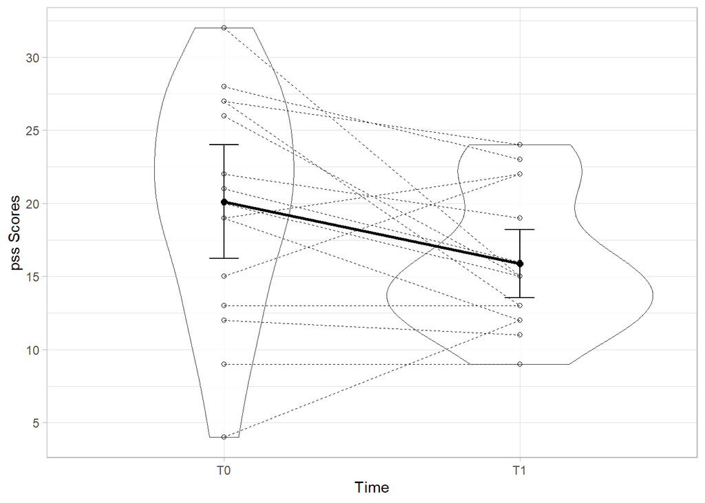

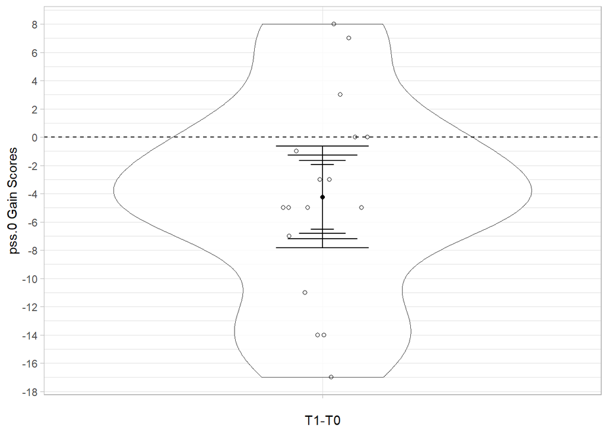

```r
pair.test(dv = "pss", long.dataset = dat.long, plots = TRUE, silent = TRUE)
```

## 3.3 Figure 3A

- Reproduce Figure 3A: Dot plots of aerobic economy data across velocity and time for absolute oxygen cost (VO2 L/min)

```
## NOTE: Results may be misleading due to involvement in interactions
```

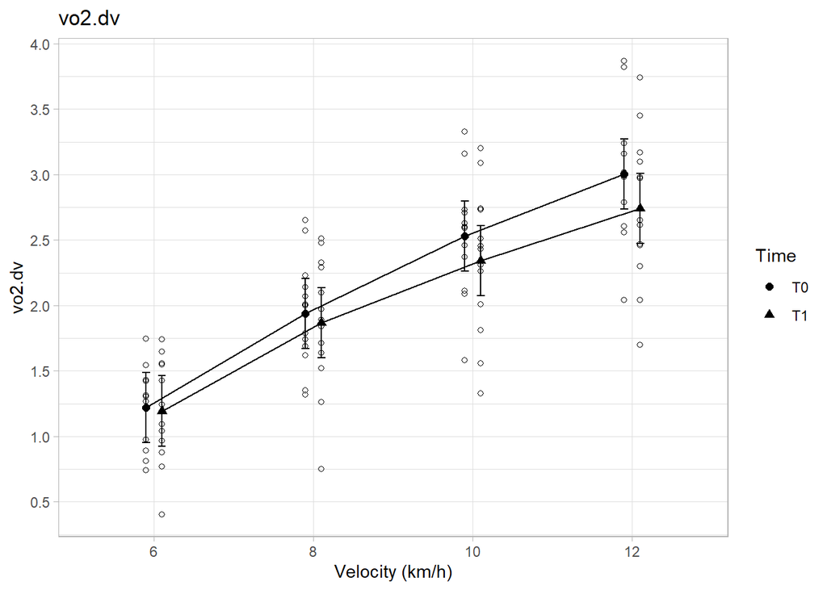

```r
emm.test(dv = "vo2.dv", long.dataset = dat.econ.long, effect = "time", plots = TRUE, silent = TRUE)
```

## 3.4 Figure 3B

- Reproduce Figure 3B: Dot plots of aerobic economy data across velocity and time for relative oxygen cost (% VO2max)

```
## NOTE: Results may be misleading due to involvement in interactions
```

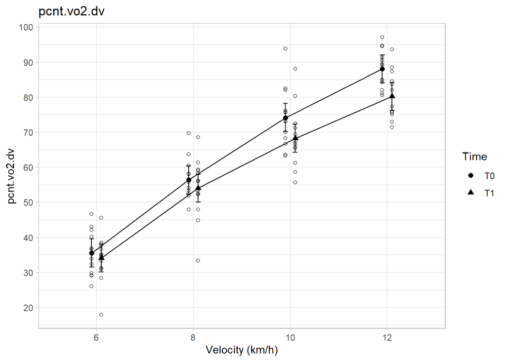

```r
emm.test(dv = "pcnt.vo2.dv", long.dataset = dat.econ.long, effect = "time", plots = TRUE, silent = TRUE)
```

## 3.5 Figure 3C

- Reproduce Figure 3C: Dot plots of aerobic economy data across velocity and time for heart rate

```
## NOTE: Results may be misleading due to involvement in interactions
```

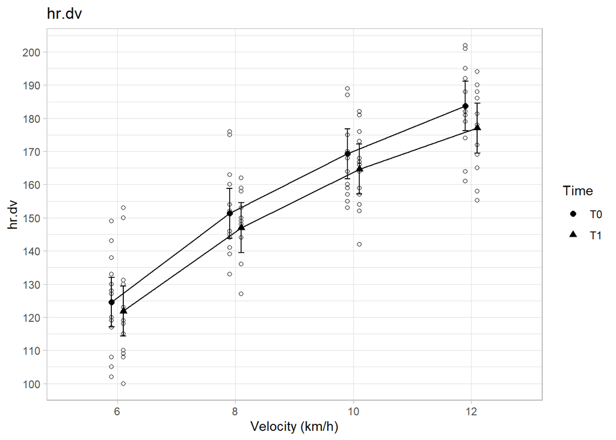

```r
emm.test(dv = "hr.dv", long.dataset = dat.econ.long, effect = "time", plots = TRUE, silent = TRUE)
```

## 3.6 Figure 3D

- Reproduce Figure 3D: Dot plots of aerobic economy data across velocity and time for perceived exertion (RPE)

```
## NOTE: Results may be misleading due to involvement in interactions
```

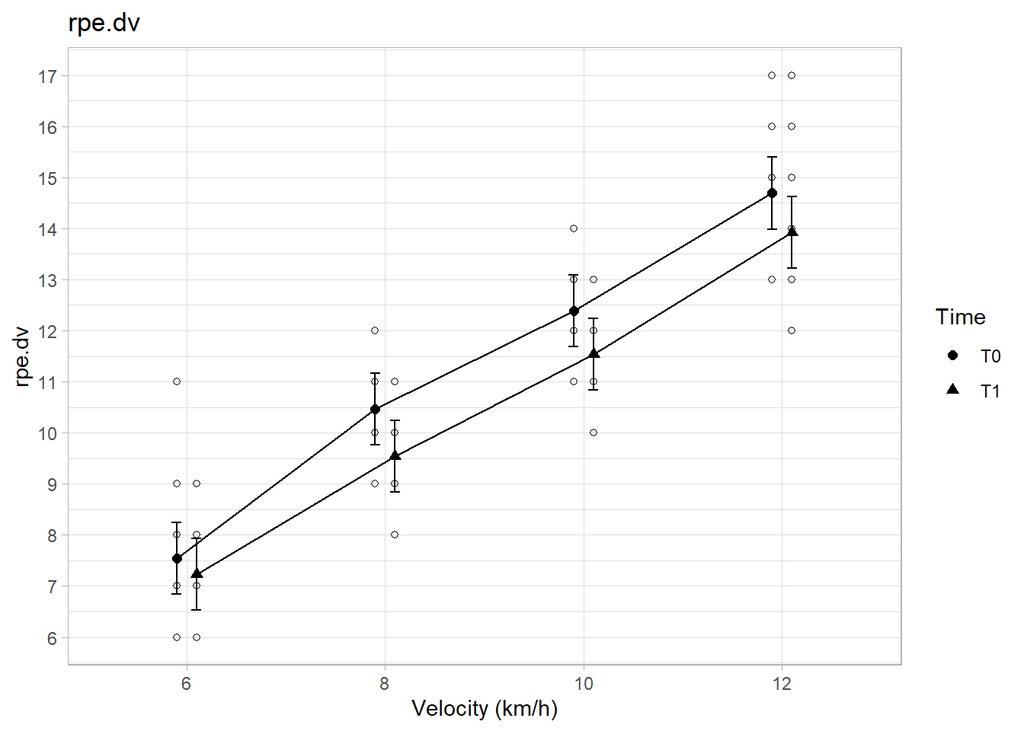

```r
emm.test(dv = "rpe.dv", long.dataset = dat.econ.long, effect = "time", plots = TRUE, silent = TRUE)
```

# 4 In-text Statistics

The following statistics are reported in the text of the main manuscript but outside of tables.

## 4.1 Critical *t* and *d* value for *N* = 17

- Reproduce calculation of the critical *t* and *d* values

```r
crit.vals(n = 17, type = "paired", alpha = 0.2)
```

```
## d.crit = 0.32, 80% CI [-0.17, 0.81], MoE = 0.49
## t.crit(16) = 1.34, p.crit = 0.200
##
## $d.crit
## ci.LL     d ci.UL
## -0.17  0.32  0.81
##
## $moe
## [1] 0.49
##
## $df
## [1] 16
##
## $t.crit
## [1] 1.34
##
## $p.crit
## [1] 0.2
```

## 4.2 Common language effect size for PSS-10 gain scores

- The common language effect size is computed with the following formula: `CL = 1 - pnorm(mu/sd.ch)`
- It quantifies the chance that a participant picked at random at T1 will have a lower PSS-10 score compared to T0

```r
pair.test(dv = "pss", long.dataset = dat.long, plots = FALSE, silent = TRUE)$gain.res$cl.ES
```

```
## [1] 0.7270334
```

## 4.3 Sensitivity test for survivorship bias in PSS-10 gain score analyses

- This test assigns a PSS-10 gain score of zero for seven participants and re-runs the paired test analysis on these gain scores

```r
pair.sensitivity(dv = "pss", dropout.n = 7, long.dataset = dat.long)
```

```
## $report
## [1] "M (SD) = -3.00 (6.17), 95% CI [-5.61, -0.39], p = 0.026, pR = 0.018"
##
## $n
## [1] 24
##
## $mu
## [1] -3
##
## $ci
## [1] -5.6059803 -0.3940197
##
## $sdev
## [1] 6.171463
##
## $min
## [1] -17
##
## $max
## [1] 8
##
## $tval
## [1] -2.381435
##
## $df
## [1] 23
##
## $pval
## [1] 0.02590655
##
## $r.pval
## [1] 0.018
##
## $dz
## [1] -0.4861084
```

## 4.4 Feasibility Rates

- Reproduce the feasibility rates

```r
feasibility(values = "f.rates")
```

```
## $`Retention Rate`
##      n.nonrandomized n.completed retention.rate
## [1,]              24          17       70.83333
##
## $`Dropout Rate`
##      n.nonrandomized n.dropout dropout.rate
## [1,]              24         7     29.16667
##
## $`Questionnaire response rate`
##      n.quest response.rate.quest
## [1,]      17                 100
##
## $`VO2max response rate`
##      n.vo2max response.rate.vo2max
## [1,]       17                  100
##
## $`Aerobic Economy rate: 6 km/h`
##      n.economy.6km ae.rate.6km
## [1,]            17         100
##
## $`Aerobic Economy rate: 8 km/h`
##      n.economy.8km ae.rate.8km
## [1,]            17         100
##
## $`Aerobic Economy rate: 10 km/h`
##      n.economy.10km ae.rate.10km
## [1,]             14     82.35294
##
## $`Aerobic Economy rate: 12 km/h`
##      n.economy.12km ae.rate.12km
## [1,]             13     76.47059
##
## $`Aerobic Economy rate: 14 km/h`
##      n.economy.14km ae.rate.14km
## [1,]              4     23.52941
##
## $`Recruitment Rate`
##      n.applied n.nonrandomized recruitment.rate
## [1,]        45              24         53.33333
##
## $`Eligibility inclusion rate`
##      n.applied n.eligible elig.rate
## [1,]        45         28  62.22222
##
## $`Primary reasons for ineligibility`
##                                                                                      Reason
## 7 Engagement in regular meditation practice within six months prior to the first assessment
## 3                                    Current diagnosis of a neurological or mental disorder
## 8    Engagement in regular running training within six months prior to the first assessment
##   Freq     %
## 7    4 23.53
## 3    2 11.76
## 8    2 11.76
```

## 4.5 Safeguard effect size

- Reproduce the safeguard effect size computation for PSS-10 gain scores

```r
safeguard.es(dv = "pss", long.dataset = dat.long, type = "dz", silent = TRUE)$ci.LL_0.80
```

```
## [1] -0.3716281
```

# 5 Sample Size Planning Analyses

## 5.1 Delta-z = -0.60

```r
aipe.d(d = -0.6,
       type = "dz",
       conf.level = 0.95,
       assurance = 0.99,
       retention.rate = 0.71)
```

```
##       d moe  n n.adj
## dz -0.6 0.3 63    89
```

## 5.2 Delta-z = -0.37

```r
aipe.d(d = -0.37,
     type = "dz",
     conf.level = 0.95,
     assurance = 0.99,
     retention.rate = 0.71)
```

```
##        d   moe   n n.adj
## dz -0.37 0.185 132   186
```

## 5.3 Delta-s

```r
aipe.mult.d(dvals = seq(0.2, 0.8, 0.1),
            type = "ds",
            conf.level = 0.95,
            assurance = 0.99,
            return.order.d = "descending",
            retention.rate = 0.71)
```

```
##       d  moe   n n.adj
## ds1 0.8 0.40  59    84
## ds2 0.7 0.35  73   103
## ds3 0.6 0.30  96   136
## ds4 0.5 0.25 133   188
## ds5 0.4 0.20 202   285
## ds6 0.3 0.15 352   496
## ds7 0.2 0.10 779  1098
```

# 6 Supplementary Results Tables

## 6.1 Table 1

- Reproduce Supplementary Results Table 1: Summarized results for gains (T1-T0) at multiple confidence limits for psychosocial stress factors, mindfulness, emotion regulation factors, and maximal aerobic capacity

```r
pair.multiconf2(dvs = c("pss",
                       "sdass",
                       "adass",
                       "ddass",
                       "who",
                       "maas",
                       "erq.cr",
                       "rrs.br",
                       "pswq",
                       "vo2max"),
               long.dataset = dat.long,
               sav2csv = TRUE,
               sav2dir = c("results", "tables", "supp_table1.csv"))
```

|  | Gain | 80% CI | 95% CI | p |
| --- | --- | --- | --- | --- |
| pss_M | -4.24 | [-6.51, -1.96] | [-7.84, -0.63] | .024 |
| pss_d_pre | -0.56 | [-0.91, -0.22] | [-1.14, -0.06] |  |
| sdass_M | -4.59 | [-5.94, -3.24] | [-6.73, -2.44] | &lt;.001 |
| sdass_d_pre | -0.76 | [-1.01, -0.58] | [-1.24, -0.52] |  |
| adass_M | 0.12 | [-1.36, 1.59] | [-2.22, 2.46] | .916 |
| adass_d_pre | 0.02 | [-0.27, 0.35] | [-0.43, 0.53] |  |
| ddass_M | -4.00 | [-6.05, -1.95] | [-7.25, -0.75] | .019 |
| ddass_d_pre | -0.56 | [-0.81, -0.27] | [-0.98, -0.15] |  |
| who_M | 9.65 | [4.54, 14.75] | [1.55, 17.75] | .023 |
| who_d_pre | 0.52 | [0.29, 0.82] | [0.19, 1.02] |  |

[output cut: 10 more lines]

## 6.2 Table 2

- Reproduce Supplementary Results Table 2: Summarized results for follow-up pairwise contrast gains (T1-T0) at multiple confidence limits for the fixed effect of time (absolute oxygen cost, relative oxygen cost, heart rate, and perceived exertion) and interaction (relative oxygen cost)

```r
lmm.supp.res(dvs = c("vo2.dv",
                       "pcnt.vo2.dv",
                       "hr.dv",
                       "rpe.dv"),
               long.dataset = dat.econ.long,
               sav2csv = TRUE,
               sav2dir = c("results", "tables", "supp_table2.csv"))
```

```
## NOTE: Results may be misleading due to involvement in interactions
## NOTE: Results may be misleading due to involvement in interactions
## NOTE: Results may be misleading due to involvement in interactions
## NOTE: Results may be misleading due to involvement in interactions
```

|  | name | gain | 80% CI | 85% CI | 90% CI | 95% CI | p |
| --- | --- | --- | --- | --- | --- | --- | --- |
| 1 | vo2.time | -0.14 | [-0.20, -0.07] | [-0.21, -0.06] | [-0.22, -0.05] | [-0.24, -0.04] | .007 |
| 2 | pcnt.vo2.time | -4.37 | [-5.77, -2.96] | [-5.95, -2.79] | [-6.18, -2.56] | [-6.53, -2.20] | &lt;.001 |
| 3 | pcnt.vo2.int | -1.42 | [-4.23, 1.40] | [-4.58, 1.75] | [-5.04, 2.21] | [-5.75, 2.91] | .517 |
| 4 | pcnt.vo2.int | -2.34 | [-5.15, 0.48] | [-5.50, 0.83] | [-5.96, 1.29] | [-6.67, 1.99] | .286 |
| 5 | pcnt.vo2.int | -5.91 | [-8.72, -3.09] | [-9.07, -2.74] | [-9.53, -2.28] | [-10.24, -1.57] | .008 |
| 6 | pcnt.vo2.int | -7.81 | [-10.63, -5.00] | [-10.98, -4.65] | [-11.43, -4.19] | [-12.14, -3.48] | .001 |
| 7 | hr.time | -4.56 | [-6.63, -2.50] | [-6.89, -2.24] | [-7.23, -1.90] | [-7.75, -1.38] | .005 |
| 8 | rpe.time | -0.71 | [-0.96, -0.47] | [-0.99, -0.43] | [-1.03, -0.39] | [-1.09, -0.33] | &lt;.001 |

## 6.3 Table 3

- Reproduce Supplementary Results Table 3: Summarized results of the linear mixed model for absolute oxygen cost (Oc)

```r
supp.model(dv = "vo2.dv",
           long.dataset = dat.econ.long,
           sav2csv = TRUE,
           sav2dir = c("results", "tables", "supp_table3.csv"))
```

|  | 1 | 2 | 3 | 4 | 5 |
| --- | --- | --- | --- | --- | --- |
| 1 | logLik | AIC | LRT | Df | Pr(&gt;Chisq) |
| &lt;none&gt; | -38.17 | 96.34 |  |  |  |
| (1 \| id) | -78.74 | 175.48 | 81.14 | 1 | &lt;.001 |

|  | 1 | 2 | 3 | 4 | 5 |
| --- | --- | --- | --- | --- | --- |
| 1 | Estimate | Std. Error | df | t value | Pr(&gt;\|t\|) |
| (Intercept) | 2.10 | 0.11 | 12.00 | 18.90 | &lt;.001 |
| time1 | 0.07 | 0.02 | 84.00 | 2.75 | .007 |
| samp1 | -0.90 | 0.04 | 84.00 | -20.88 | &lt;.001 |
| samp2 | -0.20 | 0.04 | 84.00 | -4.69 | &lt;.001 |
| samp3 | 0.33 | 0.04 | 84.00 | 7.69 | &lt;.001 |
| time1:samp1 | -0.05 | 0.04 | 84.00 | -1.28 | .205 |
| time1:samp2 | -0.03 | 0.04 | 84.00 | -0.79 | .430 |
| time1:samp3 | 0.03 | 0.04 | 84.00 | 0.60 | .552 |

|  | V1 | V2 |
| --- | --- | --- |
| RFX | Variance | SD |
| RFX (intercept) | 0.15 | 0.39 |
| Residual | 0.06 | 0.25 |

## 6.4 Table 4

- Reproduce Supplementary Results Table 4: Summarized results of the linear mixed model for relative oxygen cost (% VO2max).

```r
supp.model(dv = "pcnt.vo2.dv",
           long.dataset = dat.econ.long,
           sav2csv = TRUE,
           sav2dir = c("results", "tables", "supp_table4.csv"))
```

|  | 1 | 2 | 3 | 4 | 5 |
| --- | --- | --- | --- | --- | --- |
| 1 | logLik | AIC | LRT | Df | Pr(&gt;Chisq) |
| &lt;none&gt; | -327.68 | 675.36 |  |  |  |
| (1 \| id) | -341.19 | 700.38 | 27.02 | 1 | &lt;.001 |

|  | 1 | 2 | 3 | 4 | 5 |
| --- | --- | --- | --- | --- | --- |
| 1 | Estimate | Std. Error | df | t value | Pr(&gt;\|t\|) |
| (Intercept) | 61.31 | 1.37 | 12.00 | 44.66 | &lt;.001 |
| time1 | 2.18 | 0.54 | 84.00 | 4.01 | &lt;.001 |
| samp1 | -26.54 | 0.94 | 84.00 | -28.14 | &lt;.001 |
| samp2 | -6.12 | 0.94 | 84.00 | -6.49 | &lt;.001 |
| samp3 | 9.86 | 0.94 | 84.00 | 10.46 | &lt;.001 |
| time1:samp1 | -1.48 | 0.94 | 84.00 | -1.56 | .121 |
| time1:samp2 | -1.02 | 0.94 | 84.00 | -1.08 | .284 |
| time1:samp3 | 0.77 | 0.94 | 84.00 | 0.82 | .417 |

|  | V1 | V2 |
| --- | --- | --- |
| RFX | Variance | SD |
| RFX (intercept) | 20.65 | 4.54 |
| Residual | 30.82 | 5.55 |

## 6.5 Table 5

- Reproduce Supplementary Results Table 5: Summarized results of the linear mixed model for heart rate (beats/min)

```r
supp.model(dv = "hr.dv",
           long.dataset = dat.econ.long,
           sav2csv = TRUE,
           sav2dir = c("results", "tables", "supp_table5.csv"))
```

|  | 1 | 2 | 3 | 4 | 5 |
| --- | --- | --- | --- | --- | --- |
| 1 | logLik | AIC | LRT | Df | Pr(&gt;Chisq) |
| &lt;none&gt; | -369.37 | 758.75 |  |  |  |
| (1 \| id) | -399.71 | 817.42 | 60.67 | 1 | &lt;.001 |

|  | 1 | 2 | 3 | 4 | 5 |
| --- | --- | --- | --- | --- | --- |
| 1 | Estimate | Std. Error | df | t value | Pr(&gt;\|t\|) |
| (Intercept) | 154.93 | 2.99 | 12.00 | 51.89 | &lt;.001 |
| time1 | 2.28 | 0.80 | 84.00 | 2.85 | .005 |
| samp1 | -31.73 | 1.39 | 84.00 | -22.89 | &lt;.001 |
| samp2 | -5.78 | 1.39 | 84.00 | -4.17 | &lt;.001 |
| samp3 | 12.07 | 1.39 | 84.00 | 8.70 | &lt;.001 |
| time1:samp1 | -0.94 | 1.39 | 84.00 | -0.68 | .498 |
| time1:samp2 | -0.13 | 1.39 | 84.00 | -0.09 | .926 |
| time1:samp3 | 0.03 | 1.39 | 84.00 | 0.02 | .982 |

|  | V1 | V2 |
| --- | --- | --- |
| RFX | Variance | SD |
| RFX (intercept) | 107.56 | 10.37 |
| Residual | 66.62 | 8.16 |

## 6.6 Table 6

- Reproduce Supplementary Results Table 6: Summarized results of the linear mixed model for perceived exertion (RPE)

```r
supp.model(dv = "rpe.dv",
           long.dataset = dat.econ.long,
           sav2csv = TRUE,
           sav2dir = c("results", "tables", "supp_table6.csv"))
```

|  | 1 | 2 | 3 | 4 | 5 |
| --- | --- | --- | --- | --- | --- |
| 1 | logLik | AIC | LRT | Df | Pr(&gt;Chisq) |
| &lt;none&gt; | -160.46 | 340.92 |  |  |  |
| (1 \| id) | -174.08 | 366.16 | 27.24 | 1 | &lt;.001 |

|  | 1 | 2 | 3 | 4 | 5 |
| --- | --- | --- | --- | --- | --- |
| 1 | Estimate | Std. Error | df | t value | Pr(&gt;\|t\|) |
| (Intercept) | 10.91 | 0.24 | 12.00 | 45.25 | &lt;.001 |
| time1 | 0.36 | 0.10 | 84.00 | 3.73 | &lt;.001 |
| samp1 | -3.53 | 0.17 | 84.00 | -21.37 | &lt;.001 |
| samp2 | -0.91 | 0.17 | 84.00 | -5.53 | &lt;.001 |
| samp3 | 1.05 | 0.17 | 84.00 | 6.35 | &lt;.001 |
| time1:samp1 | -0.20 | 0.17 | 84.00 | -1.22 | .225 |
| time1:samp2 | 0.11 | 0.17 | 84.00 | 0.64 | .524 |
| time1:samp3 | 0.07 | 0.17 | 84.00 | 0.41 | .685 |

|  | V1 | V2 |
| --- | --- | --- |
| RFX | Variance | SD |
| RFX (intercept) | 0.64 | 0.80 |
| Residual | 0.95 | 0.97 |